# Explore and Summarize data of Red Wines

## Multivariate Analysis

#### Talk about some of the relationships you observed in this part of the investigation. Were there features that strengthened each other in terms of looking at your feature(s) of interest?

Alcohol was the variable whch influences the quality rating of wines most.Now I tried to find out which other varible combination are influencing factors.  
One of the most interesting cominations to me was the residual sugar in combination with the total acidity. We can see a trend that wines with lower quality (rating 3 and 4) have a negative correlation between sugar and acidity whereas high quality wines have a positiv correllation (more sugar means more acidity.) I expected that but could not prove it before.  
Also the high sulphates and low chlorides for the high quality wines show a trend where we may predict whether a wine is of high qulity or not.

#### Were there any interesting or surprising interactions between features?

Fixed acidity and alcohol both have high correllation with density. Very surprising that alcohol has much less influence on the density of wines than fixed acidity.

# Final Plots and Summary

## Plot One

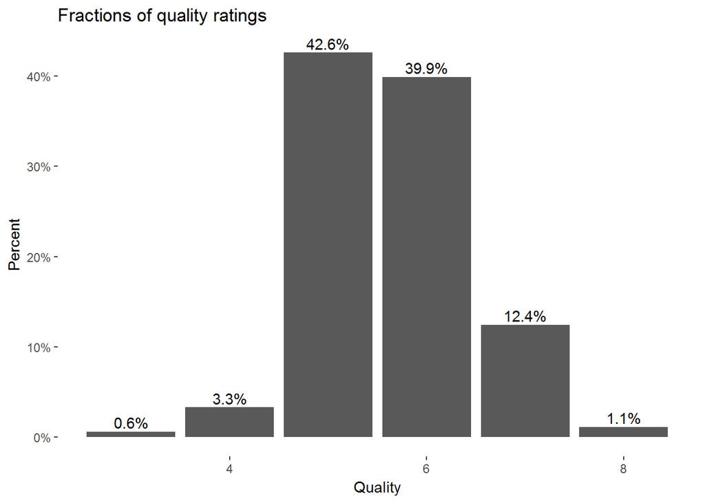

Very important is the histogram for the quality rating. It gives us an overview about the dataset and the subjective output of all samples. This is the entry to all further analysis and represents the starting point for an exploration journey.

## Plot Two

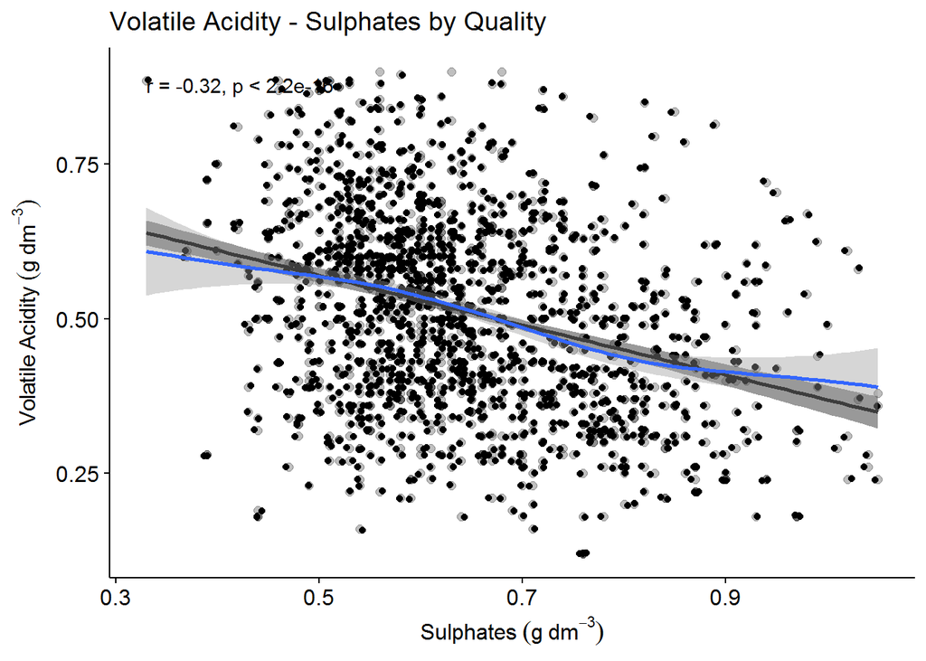

## Plot Three

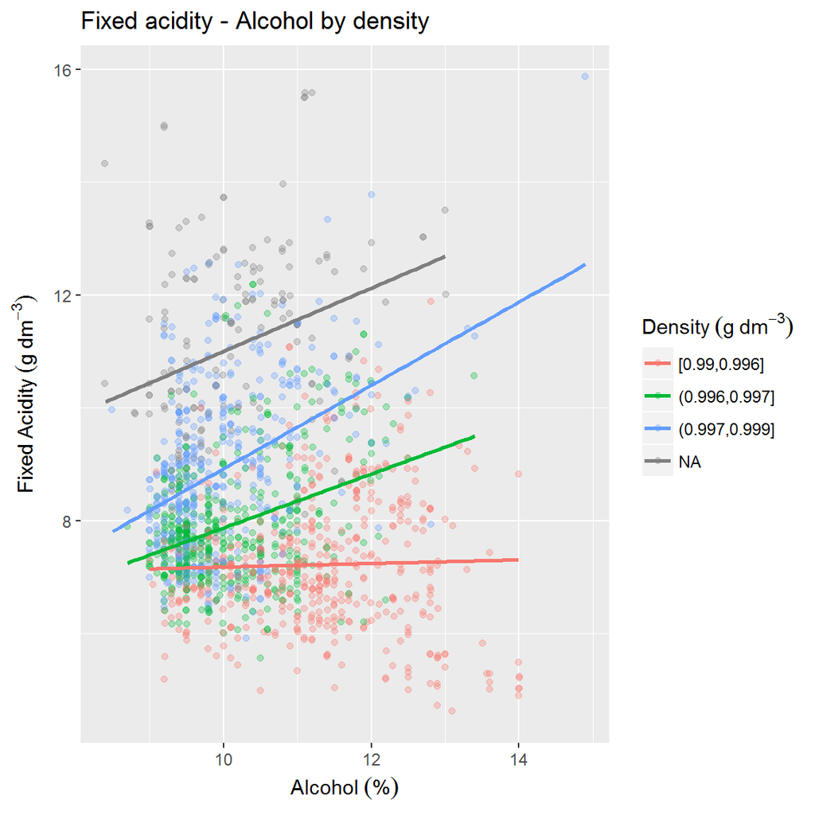

The fixed acidity has a positive correlation to density whereas alcohol is negatively correlated with density. The most interesting is that the fixed acidity has a bigger impact on the densitiy than alcohol.

# Reflection

**Is alcohol related to the wine quality?** Yes- the higher alcohol content the higher the quality ratig.

**Does the combination of residual sugar and acidity have influence on the quality?**  
Yes the higher both values are the higher the wine is rated.

## Ressources

http://wineserver.ucdavis.edu/industry/enology/methods_and_techniques/reagents/citric_acid.html http://en.wikipedia.org/wiki/Sweetness_of_wine#Residual_sugar https://en.wikipedia.org/wiki/PH